# Group 14: MDS 522 : Members: Quan Hoang, Mailys Guegon, Joel Peterson, Li Pu

Analyzing the **realDonaldTrump_in_office.csv** from https://github.com/MarkHershey/CompleteTrumpTweetsArchive/blob/master/data/realDonaldTrump_in_office.csv

# Summary

Here we are analyzing Tweets published by Donald Trump during his first presidency, specifically how the time of day or season affect the frequency of the tweets. Additionally, we did sentiment analysis using a VADER for classification to determine the frequency of positive, negative and neutral tweets. Finally, using a combination of CountVectorizer and Logistic Regression, we used WorldCloud visualization to determine the most frequent positive and negative words.

## Introduction

Twitter (also known as X) is one of the world's most popular social media platforms, where users can share short messages (texts, videos, photos) known as tweets. In April 2025, the Pew Research Center did a study and found that on average active users published 157 tweets per month, which is around 5 tweets per day. At the beginning of his first presidency, Donald Trump followed the average, posting about 5.7 times per day. However towards the second half of 2020, his posting rate grew to around 34.8 times per day. On June 5 2020, he went as far as tweeting or retweeting 200 messages in a single day. With so much data, we though it would be interesting to consider what could affect his frequency of posting. The president uses the platform mostly to disparage those he perceives as threats (people, companies, countries...), with more than half of his tweets between January 2017 and October 2019 being used to attack something or someone. Another intresting question to consider would be to determine the frequency of positive and negative tweets throughout his presidency. In this report, we will start by considering different the factors (time of day or season) that might have an impact on the frequency of the tweets, then we will classify the tweets into positive, negative or neutral to determine the most frequent sentiment expressed in his posts.

## Analysis

### Part 1: Does the time of day/period of the year affect the frequency of the tweets?

```python
import pandas as pd
import altair as alt
import requests
import pandera.pandas as pa
from pandera.pandas import Column, DataFrameSchema

def load_clean_trump_csv(url):                # chatGPT assistance to construct this data-cleaning function from URL
    resp = requests.get(url)                   # download the csv text from passed URL
    resp.raise_for_status()                     # raise if 4xx/5xx
    lines = resp.text.splitlines()

    rows = []

    for i, line in enumerate(lines, start=1):
        line = line.rstrip("\n\r")
        if not line.strip():
            continue                                   # skip empty lines

        parts = line.split(",")

        if i == 1:                                        # skip header row => define custom column names later
            continue

        if len(parts) < 4:                                  # if fewer than 4 parts => it's truly broken => drop
            continue

        id_val = parts[0].strip()                              # the first 3 columns don't need cleaning
        time_val = parts[1].strip()
        url_val = parts[2].strip()
        tweet_text = ",".join(parts[3:]).strip()

        rows.append((id_val, time_val, url_val, tweet_text))

    df = pd.DataFrame(rows, columns=["ID", "Time", "Tweet URL", "Tweet Text"])
    return df


url = "https://raw.githubusercontent.com/MarkHershey/CompleteTrumpTweetsArchive/refs/heads/master/data/realDonaldTrump_in_office.csv"

tweets = load_clean_trump_csv(url)

tweets.columns = tweets.columns.str.strip()                                # strip white-space from before column names
#print(tweets.columns)
tweets["Date & Time"] = pd.to_datetime(tweets["Time"], errors="coerce")     # set Time column to DateTime and rename
tweets = tweets.drop(columns=["ID", "Tweet URL", "Time"])                     # drop ID => twitter-handle, Tweet URL, Time => now "Date & Time"

print(tweets.shape)
tweets.head(10)
```

```
(23075, 2)
```

|  | Tweet Text | Date & Time |
| --- | --- | --- |
| 0 | "It all begins today! I will see you at 11:00 ... | 2017-01-20 06:31:00 |
| 1 | "Today we are not merely transferring power fr... | 2017-01-20 11:51:00 |
| 2 | "power from Washington, D.C. and giving it bac... | 2017-01-20 11:51:00 |
| 3 | "What truly matters is not which party control... | 2017-01-20 11:52:00 |
| 4 | "January 20th 2017, will be remembered as the ... | 2017-01-20 11:53:00 |
| 5 | "The forgotten men and women of our country wi... | 2017-01-20 11:54:00 |
| 6 | "We will bring back our jobs. We will bring ba... | 2017-01-20 11:54:00 |
| 7 | "We will follow two simple rules: BUY AMERICAN... | 2017-01-20 11:55:00 |
| 8 | "It is time to remember that...https://www.fac... | 2017-01-20 11:58:00 |
| 9 | "So to all Americans, in every city near and f... | 2017-01-20 12:00:00 |

**DATA VALIDATION: Panderas**

```python
schema = DataFrameSchema(
    {
        "Date & Time": Column(pa.DateTime, nullable=False, coerce=True),
        "Tweet Text": Column(pa.String, nullable=False),
    }
)

tweets_valid = schema.validate(tweets)
```

- The initial data filtering by time of day visualized in the bar chart shows that the highest frequency of tweets occurs during the evening period between 4:01 pm - 12:00 am (as mentioned above) with a total of 8825 analyzed tweets. The second most frequent tweet period occurred during the overnight period between 12:01 am - 8:00 am with a total of 7881 analyzed tweets, with the time of day resulting in the least frequent amount of tweets actually being the daytime period between 8:01am-4:00pm with a total of 6369 analyzed tweets. Perhaps this is because Trump is most busy during the day (golfing?) and cannot tend to tweets.

```python
tweets = tweets.set_index("Date & Time")                                  # set index to DateTime for filtering


daytime = tweets.between_time("08:01", "16:00")                             # 8:01 am - 4:00 pm
evening = tweets.between_time("16:01", "00:00")                              # 4:01 pm - 12:00 am
overnight = tweets.between_time("00:01", "08:00")                             # 12:01 am - 8:00 am

print(f"The number of tweets in the 'Daytime' category is: {len(daytime)}")
print(f"The number of tweets in the 'Evening' category is: {len(evening)}")
print(f"The number of tweets in the 'Overnight' category is: {len(overnight)}")

print("Just by the distribution of tweets it is surprisingly evenly spread; with the most tweets happening in the evening.")
```

```
The number of tweets in the 'Daytime' category is: 6369
The number of tweets in the 'Evening' category is: 8825
The number of tweets in the 'Overnight' category is: 7881
Just by the distribution of tweets it is surprisingly evenly spread; with the most tweets happening in the evening.
```

```python
tweet_time = pd.DataFrame({
    "Time": ["daytime", "evening", "overnight"],
    "Count": [len(daytime), len(evening), len(overnight)]
})

tweet_time
```

|  | Time | Count |
| --- | --- | --- |
| 0 | daytime | 6369 |
| 1 | evening | 8825 |
| 2 | overnight | 7881 |

Figure 1: Number of tweets published by time of day (daytime: 8:01 am - 4:00 pm, evening: 4:01 pm - 12:00 am, overnight: 12:01 am - 8:00 am )

- The seasonal filtering of the tweets returned the results of the most frequent amount of tweets being in the summer with 6747 analyzed tweets, with the autumn being the second busiets season for tweets resulting in 6401 analysed tweets, followed by the spring recording 5543 analyzed tweets, and lastly the winter being the least busy season for tweets recording a number of 4384 tweets. This falls inline with inutitive assumptions about mood and activity as the summer is usually the busiest with longer days (daylight) and nicer weather, then the fall slowly tapers off into the winter season being the shortest days for daylight and the most restricting weather.

```python
tw = pd.Series(tweets.index.strftime('%m-%d'), index=tweets.index)     # ChatGPT assistance to troubleshoot filtering datetimes in index

spring = tweets.loc[tw.between('04-01', '06-30')]                    # April 1st - June 30th
summer = tweets.loc[tw.between('07-01', '09-30')]                   # July 1st - September 30th
autumn = tweets.loc[tw.between('10-01', '12-31')]                  # October 1st - December 31st
winter = tweets.loc[tw.between('01-01', '03-31')]                 # January 1st - March 31st

print(f"The number of tweets in the 'Spring' category is: {len(spring)}")
print(f"The number of tweets in the 'Summer' category is: {len(summer)}")
print(f"The number of tweets in the 'Autumn' category is: {len(autumn)}")
print(f"The number of tweets in the 'Winter' category is: {len(winter)}")
print("")
print("Judging by the distribution of tweets throughout the seasons, the frequency decays in the winter and spring and peaks in the summer")
```

```
The number of tweets in the 'Spring' category is: 5543
The number of tweets in the 'Summer' category is: 6747
The number of tweets in the 'Autumn' category is: 6401
The number of tweets in the 'Winter' category is: 4384

Judging by the distribution of tweets throughout the seasons, the frequency decays in the winter and spring and peaks in the summer
```

```python
tweet_season = pd.DataFrame({
    "Season": ["Spring", "Summer", "Autumn", "Winter"],
    "Count": [len(spring), len(summer), len(autumn), len(winter)]
})

tweet_season
```

|  | Season | Count |
| --- | --- | --- |
| 0 | Spring | 5543 |
| 1 | Summer | 6747 |
| 2 | Autumn | 6401 |
| 3 | Winter | 4384 |

Figure 2: Number of tweets published by season (Spring: April 1st - June 30th, Summer: July 1st - September 30th, Autumn: October 1st - December 31st, Winter: January 1st - March 31st)

Creating the time of day frequency charts:

```python
time_bars = alt.Chart(tweet_time).mark_bar(color="#f00808").encode(
    y = "Time:N",
    x = "Count:Q",
    ).properties(
    title="Trump's Tweet Frequency by Time of Day",
    width=500,
    height=350)

#time_bars
```

```python
label_df = pd.DataFrame({
    "Time": ["daytime", "evening", "overnight"],
    "range": ["8:01am–4:00pm", "4:01pm–12:00am", "12:01am–8:00am"],
    "Count": tweet_time["Count"].values
})
```

```python
range_text = (
    alt.Chart(label_df)
    .mark_text(
        align="center",
        baseline="middle",
        color="white",
        fontSize=16,
        dx=-80
    )
    .encode(
        y="Time:N",
        x="Count:Q",
        text="range:N"
    )
)

#time_bars + range_text
```

```python
count_text = alt.Chart(label_df).mark_text(
    align="left",
    baseline="middle",
    dx=5,
    color="black",
    fontSize=14
).encode(
    y="Time:N",
    x="Count:Q",
    text="Count:Q"
)

tweet_times = time_bars + range_text + count_text
#tweet_times
```

```python
final_time_of_day_chart = (time_bars + range_text + count_text).properties(padding={"right": 50, "top":15, "bottom":15, "left":10})   # <= add some white-space to balance appearance
final_time_of_day_chart
```

[interactive chart not shown]

Figure 3: Trump's Tweet Frequency by Time of Day

Creating the seasonal frequency charts:

```python
season_bars = alt.Chart(tweet_season).mark_bar(color="#f00808").encode(
    x="Count:Q",
    y=alt.Y("Season:N",sort=["Spring", "Summer", "Autumn", "Winter"])
    ).properties(
    title="Trump's Tweet Frequency by Season",
    width=500,
    height=350)

#season_bars
```

```python
season_label_df = pd.DataFrame({
    "Season": ["Spring", "Summer", "Autumn", "Winter"],
    "range": ["April 1st - June 30th", "July 1st – Sept 30th", "Oct 1st – Dec 31st", "Jan 1st - March 31st"],
    "Count": tweet_season["Count"].values
})
#season_label_df
```

```python
season_range_text = alt.Chart(season_label_df).mark_text(
        align="center",
        baseline="middle",
        color="white",
        fontSize=16,
        dx=-90
    ).encode(
        y=alt.Y("Season:N",sort=["Spring", "Summer", "Autumn", "Winter"]),
        x="Count:Q",
        text="range:N"
    )

#season_bars + season_range_text
```

```python
season_count_text = alt.Chart(season_label_df).mark_text(
    align="left",
    baseline="middle",
    dx=5,
    color="black",
    fontSize=14
).encode(
    y=alt.Y("Season:N",sort=["Spring", "Summer", "Autumn", "Winter"]),
    x="Count:Q",
    text="Count:Q"
)

tweet_seasons = season_bars + season_range_text + season_count_text
#tweet_seasons
```

```python
final_season_chart = (season_bars + season_range_text + season_count_text).properties(padding={"right": 50, "top":15, "bottom":15, "left":10})  # aesthetic padding

final_season_chart
```

[interactive chart not shown]

Figure 4: Trump's Tweet Frequency by Season

Visualizing our results we see that there is no major difference in posting frequency given the time of day, but there is a difference for different seasons.

```python
tweet_charts = (tweet_seasons | tweet_times).properties(padding={"right": 50, "top":25, "bottom":25, "left":25})
tweet_charts
```

[interactive chart not shown]

Figure 5: Trump's Tweet Frequency by Time of Day and Season

### Part 2: How many tweets are positive vs negative? (2 classification methods)

When we think of the tweets posted by the president, we tend to think mostly of those where he critices or attacks others. However, is this a real representation of the sentiments of his tweets? In this part we will use two different sentiment analysis models to determine the frequency of positive, negative and neutral tweets.

**Method 1:**  
We use a simple sentiment analysis model (VADER) to classify each tweet as positive, negative, or neutral, and then compare the counts, this methodological inspiration is from ChatGPT.

```python
#import nltk
from vaderSentiment.vaderSentiment import SentimentIntensityAnalyzer
sia = SentimentIntensityAnalyzer()
```

```python
tweets_q2 = tweets.copy()
tweets_q2["Tweet Text"] = tweets_q2["Tweet Text"].fillna("").astype(str)

tweets_q2["sentiment_score"] = tweets_q2["Tweet Text"].apply(
    lambda t: sia.polarity_scores(t)["compound"]
)

def score_to_label(score, pos_threshold=0.05, neg_threshold=-0.05):
    if score >= pos_threshold:
        return "positive"
    elif score <= neg_threshold:
        return "negative"
    else:
        return "neutral"

tweets_q2["sentiment_label"] = tweets_q2["sentiment_score"].apply(score_to_label)

tweets_q2[["Tweet Text", "sentiment_score", "sentiment_label"]].head(10)
```

| Date & Time | Tweet Text | sentiment_score | sentiment_label |
| --- | --- | --- | --- |
| 2017-01-20 06:31:00 | "It all begins today! I will see you at 11:00 ... | 0.0000 | neutral |
| 2017-01-20 11:51:00 | "Today we are not merely transferring power fr... | 0.2144 | positive |
| 2017-01-20 11:51:00 | "power from Washington, D.C. and giving it bac... | 0.3400 | positive |
| 2017-01-20 11:52:00 | "What truly matters is not which party control... | 0.0954 | positive |
| 2017-01-20 11:53:00 | "January 20th 2017, will be remembered as the ... | 0.0000 | neutral |
| 2017-01-20 11:54:00 | "The forgotten men and women of our country wi... | -0.6124 | negative |
| 2017-01-20 11:54:00 | "We will bring back our jobs. We will bring ba... | 0.7345 | positive |
| 2017-01-20 11:55:00 | "We will follow two simple rules: BUY AMERICAN... | 0.0000 | neutral |
| 2017-01-20 11:58:00 | "It is time to remember that...https://www.fac... | 0.0000 | neutral |
| 2017-01-20 12:00:00 | "So to all Americans, in every city near and f... | 0.0000 | neutral |

```python
sentiment_counts = (
    tweets_q2
      .groupby("sentiment_label")
      .size()
      .reset_index(name="Count")
      .rename(columns={"sentiment_label": "Sentiment"})
)

sentiment_counts
```

|  | Sentiment | Count |
| --- | --- | --- |
| 0 | negative | 6838 |
| 1 | neutral | 4404 |
| 2 | positive | 11833 |

Figure 6: Number of tweets per sentiment (negative, neutral, positive)

```python
sentiment_chart = (
    alt.Chart(sentiment_counts)
    .mark_bar()
    .encode(
        x=alt.X("Sentiment:N", sort=["positive", "neutral", "negative"]),
        y=alt.Y("Count:Q"),
        tooltip=["Sentiment", "Count"]
    )
    .properties(
        title="Number of Positive, Neutral, and Negative Tweets"
    )
)

sentiment_chart
```

[interactive chart not shown]

Figure 7: Chart Comparing the Number of Positive, Neutral, and Negative Tweets

**Method 2:**  
Using a CountVectorizer and Logistic Regression, combining with a Wordcloud visualization to determine the most frequent words in the positive and negative tweets. Syntax and bug fixing credited to ChatGPT 5.1

```
Number of weak labeled tweets: 10136
weak_label
positive    6067
negative    4069
Name: count, dtype: int64
Validation accuracy (weak labels): 0.9990138067061144
Sentiment
positive    16013
negative     7062
Name: count, dtype: int64

Most frequent words in positive tweets:
          word  count
0        great   3590
1    president   1882
```

[output cut: 41 more lines]

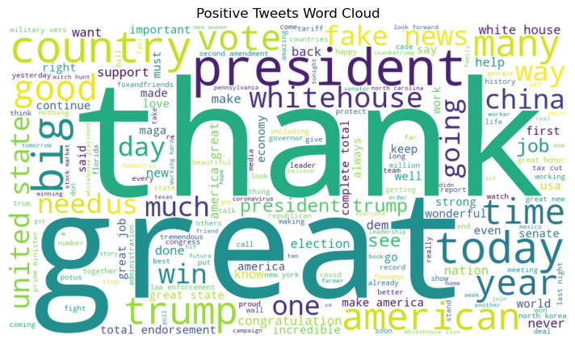

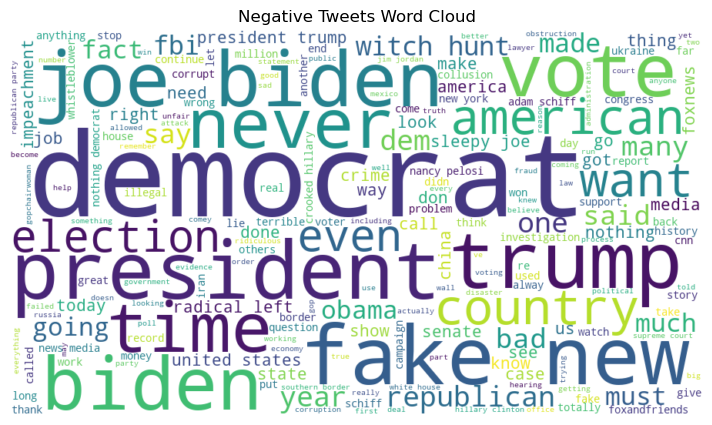

```python
import re
from collections import Counter
from wordcloud import WordCloud
import matplotlib.pyplot as plt
from sklearn.feature_extraction.text import CountVectorizer
from sklearn.linear_model import LogisticRegression
from sklearn.model_selection import train_test_split

positive_words = set("""good great amazing fantastic tremendous strong win winning beautiful success successful
happy proud respect love best positive incredible honored grateful huge strong strongest great big""".split())

negative_words = set("""bad terrible horrible weak fail failure disaster sad angry corrupt
worst negative unfair hate disgrace stupid dishonest democrat biden obama democrats sleepy joe illegal""".split())  # democrat, biden, obama usually associated negatively when Trump speaks

stopwords = set("""the a an and of to in is it this that for on with be as by are was were will from at have has but not or if so
you your my our their they we i he she his her him them rt s all t just now amp more very about do what who people word should m realdonaldtrump u""".split())

# -------------------------------------------------------------------
# 1. Helper functions
# -------------------------------------------------------------------

def simple_tokenize(text: str):
    """Lowercase everything, remove URLs and non letters, then split."""
    text = text.lower()
    text = re.sub(r"http\S+", "", text)          # remove URLs
    text = re.sub(r"[^a-z\s]", " ", text)        # keep letters and spaces
    return text.split()

def weak_label(text: str):
    """Use positive and negative lexicons to create weak labels for training."""
    if not isinstance(text, str):
        return None
    tokens = simple_tokenize(text)
    pos_hits = sum(1 for w in tokens if w in positive_words)
    neg_hits = sum(1 for w in tokens if w in negative_words)
    if pos_hits > neg_hits:
        return "positive"
    elif neg_hits > pos_hits:
        return "negative"
    else:
        return None  # ambiguous, skip from training

# -------------------------------------------------------------------
# 2. Create weak labels for a subset of tweets
# -------------------------------------------------------------------

tweets["weak_label"] = tweets["Tweet Text"].apply(weak_label)
train_df = tweets.dropna(subset=["weak_label"]).copy()

print("Number of weak labeled tweets:", len(train_df))
print(train_df["weak_label"].value_counts())

# -------------------------------------------------------------------
# 3. Train a simple ML model using CountVectorizer
# -------------------------------------------------------------------

X_train, X_test, y_train, y_test = train_test_split(
    train_df["Tweet Text"],
    train_df["weak_label"],
    test_size=0.2,
    random_state=42,
    stratify=train_df["weak_label"]
)

vectorizer = CountVectorizer(stop_words=list(stopwords), min_df=3)
X_train_vec = vectorizer.fit_transform(X_train.fillna(""))
X_test_vec = vectorizer.transform(X_test.fillna(""))

clf = LogisticRegression(max_iter=2000)
clf.fit(X_train_vec, y_train)

print("Validation accuracy (weak labels):", clf.score(X_test_vec, y_test))

# -------------------------------------------------------------------
# 4. Predict sentiment for all tweets (positive vs negative)
# -------------------------------------------------------------------

all_X = vectorizer.transform(tweets["Tweet Text"].fillna(""))
tweets["Sentiment"] = clf.predict(all_X)

print(tweets["Sentiment"].value_counts())

# -------------------------------------------------------------------
# 5. Answer the question "What are the most frequent words in the positive and negative tweets?"
# -------------------------------------------------------------------

pos_text = " ".join(tweets[tweets["Sentiment"] == "positive"]["Tweet Text"].dropna())
neg_text = " ".join(tweets[tweets["Sentiment"] == "negative"]["Tweet Text"].dropna())

pos_tokens = [w for w in simple_tokenize(pos_text) if w not in stopwords]
neg_tokens = [w for w in simple_tokenize(neg_text) if w not in stopwords]

top_pos = Counter(pos_tokens).most_common(20)
top_neg = Counter(neg_tokens).most_common(20)

top_pos_df = pd.DataFrame(top_pos, columns=["word", "count"])
top_neg_df = pd.DataFrame(top_neg, columns=["word", "count"])

print("\nMost frequent words in positive tweets:")
print(top_pos_df)

print("\nMost frequent words in negative tweets:")
print(top_neg_df)

# -------------------------------------------------------------------
# 6. Wordcloud
# -------------------------------------------------------------------
pos_wc = WordCloud(
    width=900,
    height=500,
    background_color="white"
).generate(" ".join(pos_tokens))

plt.figure(figsize=(10, 5))
plt.imshow(pos_wc, interpolation="bilinear")
plt.axis("off")
plt.title("Positive Tweets Word Cloud")
plt.show()

neg_wc = WordCloud(
    width=900,
    height=500,
    background_color="white"
).generate(" ".join(neg_tokens))

plt.figure(figsize=(10, 5))
plt.imshow(neg_wc, interpolation="bilinear")
plt.axis("off")
plt.title("Negative Tweets Word Cloud")
plt.show()
```

Figure 8a: Table with the number of weak labeled tweets  
Figure 8b: Table with the number of tweets per sentiment (positive or negative)  
Figure 8c: Table of the most frequent words used in positive tweets  
Figure 8d: Word cloud of the positive tweets  
Figure 8e: Word cloud of the negative tweets

**~DATA VALIDATION 2: Sentiment Analysis**

### Target/response variable follows expected distribution validation:

For this question, since the dataset we used did not have a "target" column, we had to try using different methods in order to find the "sentiment" of the tweets (this has been discussed with Instructor Sky Sheng and she gave us the go ahead. As the graphs/values of the check for usiing CountVectorizer and Logistic Regression below suggest, we do see a skewness towards positive tweets, which can be surprising to many people. This is partly due to neutral tweets are lumped together with positive tweets. However, since this dataset is about Trump's tweets while he was in office, those tweets could be positive because he was the "powerful man" back then.

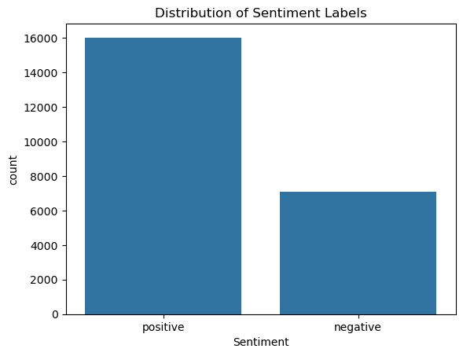

```
Sentiment
positive    0.693954
negative    0.306046
Name: proportion, dtype: float64
```

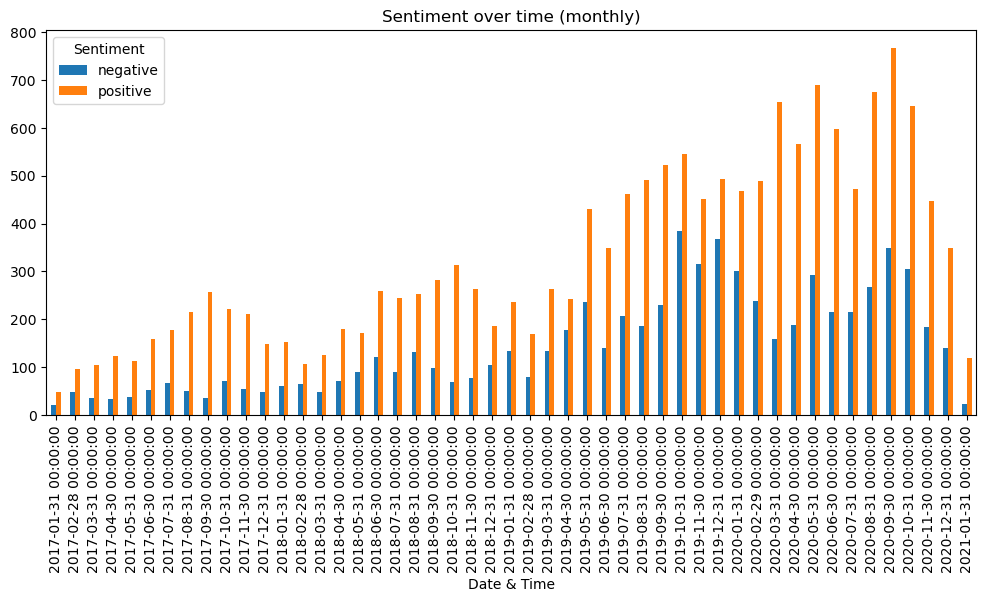

```python
# -------------------------------------------------------------------
# Data validation related to target
# -------------------------------------------------------------------
import seaborn as sns
# -------------------------------------------------------------------
# 1. Distribution of Sentiment Graph
# -------------------------------------------------------------------
sns.countplot(data=tweets, x="Sentiment")
plt.title("Distribution of Sentiment Labels")
plt.show()
# -------------------------------------------------------------------
# 2. Distribution of Sentiment Proportion
# -------------------------------------------------------------------
print(tweets["Sentiment"].value_counts(normalize=True))
# -------------------------------------------------------------------
# 3. Time-based Distribution of Sentiment Graph
# -------------------------------------------------------------------
tweets.resample("ME")["Sentiment"].value_counts().unstack().plot(kind="bar", figsize=(12,5))
plt.title("Sentiment over time (monthly)")
plt.show()
```

Figure 9a: Graph with the distribution of sentiment labels  
Figure 9b: Proportion of sentiment labels values  
Figure 9c: Graph with the distribution of sentiment labels over time

**~ DATA VALIDATION 3: Correlation**

### No anomalous correlations between target/response variable and features/explanatory variables validation:

```
             count        mean        std   min    25%    50%    75%    max
Sentiment
negative    7062.0  216.426366  73.957397  16.0  147.0  237.0  281.0  365.0
positive   16013.0  157.345157  91.493712   6.0   77.0  142.0  247.0  433.0
```

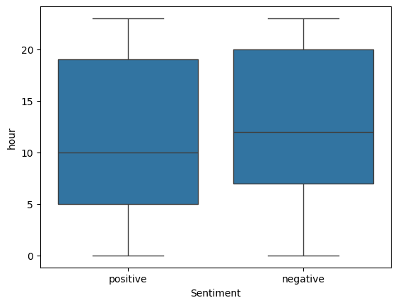

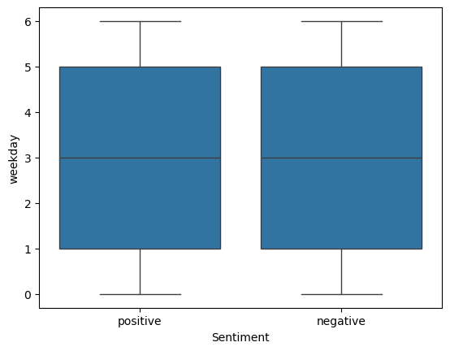

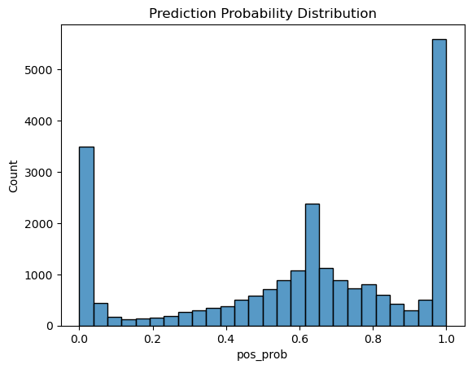

```python
# -------------------------------------------------------------------
# Data validation related to target pt.2
# -------------------------------------------------------------------

# -------------------------------------------------------------------
# 1. Numeric correlations
# -------------------------------------------------------------------
tweets["length"] = tweets["Tweet Text"].str.len()
print(tweets.groupby("Sentiment")["length"].describe())
# -------------------------------------------------------------------
# 2. Categorical correlations (hour of day, weekday)
# -------------------------------------------------------------------
tweets["hour"] = tweets.index.hour
tweets["weekday"] = tweets.index.dayofweek
sns.boxplot(data=tweets, x="Sentiment", y="hour")
plt.show()
sns.boxplot(data=tweets, x="Sentiment", y="weekday")
plt.show()
# -------------------------------------------------------------------
# 3. Model probability checks
# -------------------------------------------------------------------
probs = clf.predict_proba(vectorizer.transform(tweets["Tweet Text"]))
tweets["pos_prob"] = probs[:, 1]
sns.histplot(tweets["pos_prob"])
plt.title("Prediction Probability Distribution")
plt.show()
```

Figure 10a: Tweet length stats according to sentiments  
Figure 10b: Distribution graphs for time of day and day of the week related to sentiments  
Figure 10c: Model prediction probability distribution graph

### Correct category levels

#### Checking for string mismatches

```python
# Using pandera
import pandera.pandas as pa
from deepchecks.tabular.checks import StringMismatch

schema = pa.DataFrameSchema(
    {
        "Sentiment": pa.Column(str,
                               pa.Check.isin(["positive","negative"],error="There is a string mismatch. The correct levels are positive or negative.")),
        "weak_label": pa.Column(str, pa.Check.isin(["positive","negative"], error="The category levels are not correct (string mismatch)."), nullable=True)
    }

)

schema.validate(tweets,lazy=True)
```

| Date & Time | Tweet Text | weak_label | Sentiment | length | hour | weekday | pos_prob |
| --- | --- | --- | --- | --- | --- | --- | --- |
| 2017-01-20 06:31:00 | "It all begins today! I will see you at 11:00 ... | None | positive | 114 | 6 | 4 | 0.695553 |
| 2017-01-20 11:51:00 | "Today we are not merely transferring power fr... | None | negative | 140 | 11 | 4 | 0.301445 |
| 2017-01-20 11:51:00 | "power from Washington, D.C. and giving it bac... | None | positive | 95 | 11 | 4 | 0.591566 |
| 2017-01-20 11:52:00 | "What truly matters is not which party control... | None | negative | 120 | 11 | 4 | 0.429320 |
| 2017-01-20 11:53:00 | "January 20th 2017, will be remembered as the ... | None | positive | 101 | 11 | 4 | 0.801022 |
| ... | ... | ... | ... | ... | ... | ... | ... |
| 2021-01-07 04:13:00 | "I am asking for everyone at the U.S. Capitol ... | positive | positive | 191 | 4 | 3 | 0.999798 |
| 2021-01-07 05:17:00 | "https://t.co/Pm2PKV0Fp3" | None | positive | 25 | 5 | 3 | 0.643497 |
| 2021-01-08 08:10:00 | "https://t.co/csX07ZVWGe" | None | positive | 25 | 8 | 4 | 0.643497 |
| 2021-01-08 22:46:00 | "The 75,000,000 great American Patriots who vo... | positive | positive | 228 | 22 | 4 | 0.999971 |
| 2021-01-08 23:44:00 | "To all of those who have asked, I will not be... | None | positive | 90 | 23 | 4 | 0.623647 |

23075 rows × 7 columns

```python
# Using deepchecks
from deepchecks.tabular import Dataset

dataset = Dataset(tweets.drop('Tweet Text',axis=1), label="Sentiment", cat_features=['weak_label'])
result = StringMismatch().run(dataset)
result.show()
```

```
VBox(children=(HTML(value='<h4><b>String Mismatch</b></h4>'), HTML(value='<p>Detect different variants of stri…
```

#### Checking for single values

```python
from deepchecks.tabular.checks import IsSingleValue

sv = IsSingleValue()
sv.run(dataset)
```

```
VBox(children=(HTML(value='<h4><b>Single Value in Column</b></h4>'), HTML(value='<p>Check if there are columns…
```

### No anomalous correlations between features/explanatory variables

Using the deepchecks package to check the correlation. Since we are using bag of words it makes sense that the correlation beetween feature and label will be high (which is why we set the threshold to 0.95).  
For feature/feature, we can check if the date time has high feature correlation if we turn Date & Time column into categorical features.

```python
from deepchecks.tabular import Dataset
from deepchecks.tabular.checks.data_integrity import FeatureFeatureCorrelation
from deepchecks.tabular.checks import FeatureLabelCorrelation

trump_tweet_ds = Dataset(tweets.reset_index().drop(columns='weak_label'), label = 'Sentiment', cat_features=[])
```

```python
# Checking feature label correlation
check_feat_lab_corr = FeatureLabelCorrelation().add_condition_feature_pps_less_than(0.95)
check_feat_lab_corr_result = check_feat_lab_corr.run(dataset=trump_tweet_ds)

if not check_feat_lab_corr_result.passed_conditions():
    raise ValueError("Feature-Label correlation exceeds the maximum acceptable threshold.")

# Checking feature feature correlation
check_feat_feat_corr = FeatureFeatureCorrelation().add_condition_max_number_of_pairs_above_threshold(threshold = 0.8, n_pairs = 0)
check_feat_feat_corr_result = check_feat_feat_corr.run(dataset=trump_tweet_ds)

if not check_feat_feat_corr_result.passed_conditions():
    raise ValueError("Feature-feature correlation exceeds the maximum acceptable threshold.")

# ValueError works as expected
```

```
---------------------------------------------------------------------------
ValueError                                Traceback (most recent call last)
Cell In[31], line 6
      3 check_feat_lab_corr_result = check_feat_lab_corr.run(dataset=trump_tweet_ds)
      5 if not check_feat_lab_corr_result.passed_conditions():
----> 6     raise ValueError("Feature-Label correlation exceeds the maximum acceptable threshold.")
      8 # Checking feature feature correlation
      9 check_feat_feat_corr = FeatureFeatureCorrelation().add_condition_max_number_of_pairs_above_threshold(threshold = 0.8, n_pairs = 0)

ValueError: Feature-Label correlation exceeds the maximum acceptable threshold.
```

```python
# Creating functions to turn datetime into categorical features
def season(date):
    if 4 <= date.month <=6:
        return 'spring'
    elif 7 <= date.month <=9:
        return 'spring'
    elif 10 <= date.month <=12:
        return 'autumn'
    else:
        return 'winter'

def daytime(date):
    if pd.Timestamp('08:01').time() <= date.time() <= pd.Timestamp('16:00').time():
        return 'daytime'
    elif pd.Timestamp('16:01').time() <= date.time() <= pd.Timestamp('00:00').time():
        return 'evening'
    else:
        return 'overnight'
```

```python
# Creating functions to turn Tweet Text into categorical features
def avg_word_length(text):
    average = 0
    for word in text.split() :
        average += len(word)
    return round(average/len(text.split()),1)

def punctuation_count(text):
    count = 0
    for char in text:
        if not char.isalnum() and not char.isspace():
            count+=1
    return count
```

```python
dates_tweets = tweets.reset_index()
dates_tweets['year']=dates_tweets['Date & Time'].dt.year
dates_tweets['month']=dates_tweets['Date & Time'].dt.month
dates_tweets['day']=dates_tweets['Date & Time'].dt.day
dates_tweets['season']=dates_tweets['Date & Time'].apply(season)
dates_tweets['time_of_day']=dates_tweets['Date & Time'].apply(daytime)
dates_tweets['character_count']=dates_tweets['Tweet Text'].apply(len)
dates_tweets['avg_word_length']=dates_tweets['Tweet Text'].apply(avg_word_length)
dates_tweets['word_count']=dates_tweets['Tweet Text'].apply(lambda x:len(x.split()))
dates_tweets['punctuation_count']=dates_tweets['Tweet Text'].apply(punctuation_count)
dates_tweets.drop(columns=['weak_label','Date & Time','Tweet Text'])
```

|  | Sentiment | length | hour | weekday | pos_prob | year | month | day | season | time_of_day | character_count | avg_word_length | word_count | punctuation_count |
| --- | --- | --- | --- | --- | --- | --- | --- | --- | --- | --- | --- | --- | --- | --- |
| 0 | positive | 114 | 6 | 4 | 0.695553 | 2017 | 1 | 20 | winter | overnight | 114 | 4.5 | 21 | 10 |
| 1 | negative | 140 | 11 | 4 | 0.301445 | 2017 | 1 | 20 | winter | daytime | 140 | 5.1 | 23 | 7 |
| 2 | positive | 95 | 11 | 4 | 0.591566 | 2017 | 1 | 20 | winter | daytime | 95 | 5.4 | 15 | 8 |
| 3 | negative | 120 | 11 | 4 | 0.429320 | 2017 | 1 | 20 | winter | daytime | 120 | 5.4 | 19 | 4 |
| 4 | positive | 101 | 11 | 4 | 0.801022 | 2017 | 1 | 20 | winter | daytime | 101 | 4.7 | 18 | 4 |
| ... | ... | ... | ... | ... | ... | ... | ... | ... | ... | ... | ... | ... | ... | ... |
| 23070 | positive | 191 | 4 | 3 | 0.999798 | 2021 | 1 | 7 | winter | overnight | 191 | 4.2 | 37 | 12 |
| 23071 | positive | 25 | 5 | 3 | 0.643497 | 2021 | 1 | 7 | winter | overnight | 25 | 25.0 | 1 | 7 |
| 23072 | positive | 25 | 8 | 4 | 0.643497 | 2021 | 1 | 8 | winter | daytime | 25 | 25.0 | 1 | 7 |
| 23073 | positive | 228 | 22 | 4 | 0.999971 | 2021 | 1 | 8 | winter | overnight | 228 | 4.9 | 39 | 12 |
| 23074 | positive | 90 | 23 | 4 | 0.623647 | 2021 | 1 | 8 | winter | overnight | 90 | 4.1 | 18 | 4 |

23075 rows × 14 columns

```python
# Checking feature feature correlation

date_time_ds = Dataset(dates_tweets, label = 'Sentiment', cat_features=['year','month','day','season','time_of_day'])
check_feat_feat_corr = FeatureFeatureCorrelation().add_condition_max_number_of_pairs_above_threshold(threshold = 0.9, n_pairs = 1)
check_feat_feat_corr_result = check_feat_feat_corr.run(dataset=date_time_ds)

if not check_feat_feat_corr_result.passed_conditions():
    raise ValueError("Feature-feature correlation exceeds the maximum acceptable threshold.")

# ValueError works as expected
```

```
---------------------------------------------------------------------------
ValueError                                Traceback (most recent call last)
Cell In[36], line 8
      5 check_feat_feat_corr_result = check_feat_feat_corr.run(dataset=date_time_ds)
      7 if not check_feat_feat_corr_result.passed_conditions():
----> 8     raise ValueError("Feature-feature correlation exceeds the maximum acceptable threshold.")
     10 # ValueError works as expected

ValueError: Feature-feature correlation exceeds the maximum acceptable threshold.
```

```python
correlation_matrix = dates_tweets.drop(columns=['weak_label','Date & Time','Tweet Text','Sentiment','season','time_of_day','year','month','day']).corr()
correlation_long = correlation_matrix.reset_index().melt(id_vars='index')
correlation_long.columns = ['Feature 1', 'Feature 2', 'Correlation']

alt.Chart(correlation_long).mark_rect().encode(
    x='Feature 1:O',
    y='Feature 2:O',
    color=alt.Color('Correlation:Q', scale=alt.Scale(scheme='viridis')),
    tooltip=['Feature 1', 'Feature 2', 'Correlation']
).properties(
    width=600,
    height=600,
    title="Correlation Heatmap"
)
```

[interactive chart not shown]

### Correct data types in each column

To ensure that our dataset is clean and ready for downstream analysis, we first verify that each column has the correct data type. Since our dataset contains text, sentiment labels, and a timestamp index, incorrect types (such as strings for dates) could break the analysis or produce misleading results. Below, we inspect and correct data types as needed.

```python
print("Column data types:")
print(tweets.dtypes)

# Check whether datetime exists either as a column OR as index
if isinstance(tweets.index, pd.DatetimeIndex):
    print("\nDatetime index detected — dates are correctly parsed as index.")
else:
    if "Date" in tweets.columns:
        print("\n'Date' column exists — check first few values:")
        print(tweets["Date"].head())
    else:
        print("\nNo datetime information found (neither column nor index).")
```

```
Column data types:
Tweet Text     object
weak_label     object
Sentiment      object
length          int64
hour            int32
weekday         int32
pos_prob      float64
dtype: object

Datetime index detected — dates are correctly parsed as index.
```

### No duplicates observations

```python
dup_count = tweets.duplicated().sum()
print(f"Number of duplicated rows: {dup_count}")

# If duplicates exist, remove them
if dup_count > 0:
    tweets = tweets.drop_duplicates()
    print("Duplicates removed.")
else:
    print("No duplicate observations found.")
```

```
Number of duplicated rows: 51
Duplicates removed.
```

### No outlier or anomalous values

```
Length descriptive statistics:
count    23024.000000
mean       175.489663
std         90.647064
min          6.000000
25%        100.000000
50%        168.000000
75%        270.000000
max        433.000000
Name: length, dtype: float64
```

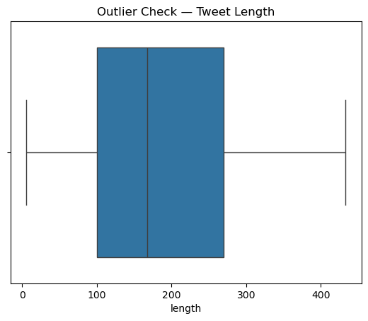

```
Number of detected outliers: 0
```

```python
tweets["length"] = tweets["Tweet Text"].str.len()

print("Length descriptive statistics:")
print(tweets["length"].describe())

# Boxplot to visualize outliers
sns.boxplot(data=tweets, x="length")
plt.title("Outlier Check — Tweet Length")
plt.show()

# Using IQR rule to detect outliers
Q1 = tweets["length"].quantile(0.25)
Q3 = tweets["length"].quantile(0.75)
IQR = Q3 - Q1
lower_bound = Q1 - 1.5 * IQR
upper_bound = Q3 + 1.5 * IQR

outliers = tweets[(tweets["length"] < lower_bound) | (tweets["length"] > upper_bound)]
print(f"Number of detected outliers: {outliers.shape[0]}")
```

## References

Gottfried, J., Park, E., & Nolan, H. (n.d.). Americans’ Social Media Use 2025 Growing shares of U.S. adults say they are using Instagram, TikTok, WhatsApp and Reddit, but YouTube still rises to the top FOR MEDIA OR OTHER INQUIRIES. Retrieved November 21, 2025, from https://www.pewresearch.org/wp-content/uploads/sites/20/2025/11/PI_2025.11.20_Social-Media-Use_REPORT.pdf  
McCarthy, N. (2021, January 11). Infographic: End Of The Road For Trump’s Twitter Account. Statista Daily Data; Statista. https://www.statista.com/chart/19561/total-number-of-tweets-from-donald-trump/?srsltid=AfmBOorYyvrCIBJxWCwAxW5yYEl6cPXzdhu-oMfRfAPfoXrcdpIEA3fy  
Mythili Sampathkumar. (2018, January 17). The tweets that have defined Donald Trump’s presidency | The Independent. The Independent. https://www.independent.co.uk/news/world/americas/us-politics/donald-trump-twitter-president-first-year-a8163791.html  
Shear, M. D., Haberman, M., Confessore, N., Yourish, K., Buchanan, L., & Collins, K. (2019, November 2). How Trump Reshaped the Presidency in Over 11,000 Tweets. The New York Times. https://www.nytimes.com/interactive/2019/11/02/us/politics/trump-twitter-presidency.html